# Statistical inference with the GSS data

## Setup

### Load packages

```r
library(ggplot2)
library(dplyr)
library(statsr)
```

### Load data

Make sure your data and R Markdown files are in the same directory. When loaded your data file will be called `gss`. Delete this note when before you submit your work.

```r
load("gss.Rdata")
```

## Part 1: Data

The survey was conducted by questionaire. The populations in the survey is people in United States. Becuase the questions in the survey is asking for the opinions of people, the varibles are categorical variables. There are 57061 observations and 114 variables in the dataset. The data was collected by romdom smapling and quesitons. Therefore, it can only answer the generalizability of an inference.

## Part 2: Research question

My first question is “what proportion of American in 1972 would report that they are Catholic?”. One will be interested in this question becuase the result would be a important indicator that shows the religious change of American. Analayzing the results, historians can see the trend of religion in historical view.

My second question is “In 1972, is there a difference between the proportion of female who believe in Cathoic and the proportion of male?” The result of this question will answer more sepcific quesitons to historian who are interested in the religious change.

My third question is“In 1972, is there a difference between the proportion of female who earned above avarage income and the proportion of male?” The result of the question can build a more specific social demographic of people in 1972. It will help historians what might cause the religious change even though my quesiton only answer the associaiton of variables but not the causality.

## Part 3: Exploratory data analysis

The code here made a new table that ontains only the data recorded at 1972 and has four variables(year, sex, religious status, Cathoic/Non-Catholic)

```r
Religious<-gss%>%
  filter(relig!= "NA", year=="1972")%>%
  select(year,sex, relig)
Religious<-Religious%>%
  mutate(True_false= ifelse(relig=="Catholic", yes="Catholic", no="Non-Catholic"))
```

This histogram describes the spread of religion in 1972

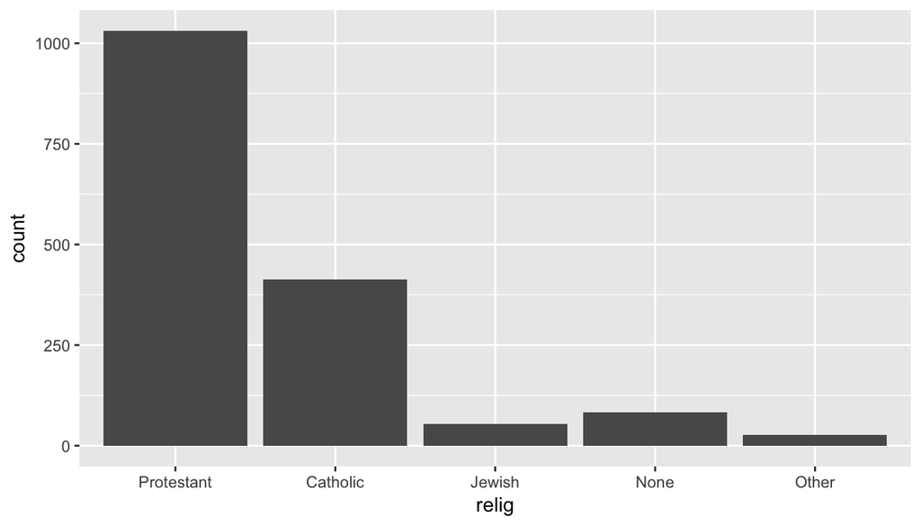

```r
ggplot(data = Religious, aes(x= relig))+geom_bar()
```

There are more poeple who reported religon other than Catholic.

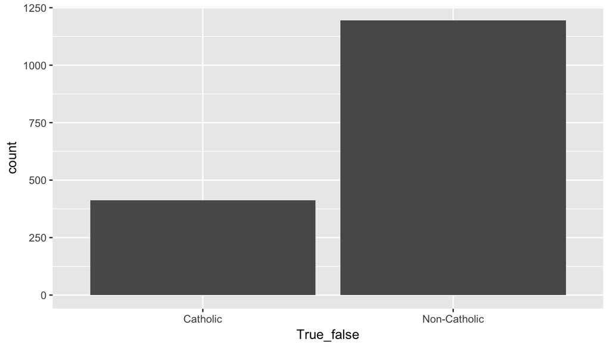

```r
ggplot(data = Religious, aes(x= True_false))+geom_bar()
```

The number of male and female are almost the same.

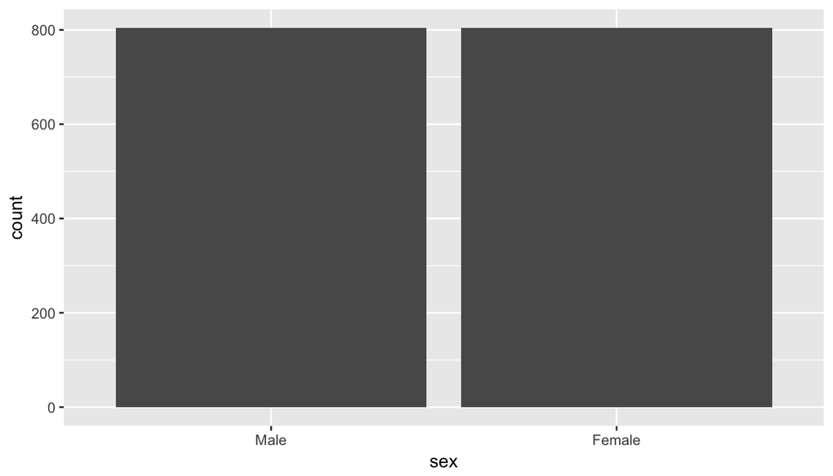

```r
ggplot(data = Religious, aes(x= sex))+geom_bar()
```

The code made a new table that contains only the data from 1972 and has four variables(Year, sex, Income status, Above Average/Not-Above Average)

```r
Income_status<-gss%>%
  filter(incom16!= "NA", year=="1972")%>%
  select(year,sex, incom16)
Income_status<-Income_status%>%
  mutate(Above_avg= ifelse(incom16=="Above Average", yes="Above Average", no="Non-Above Average"))
Religious%>%
  count(relig=="Catholic")
```

```
## # A tibble: 2 x 2
##   `relig == "Catholic"`     n
##                   <lgl> <int>
## 1                 FALSE  1195
## 2                  TRUE   413
```

This chart shows how many people beliebe Catholic and how many people do not in 1972.

The spread of income status. The avarage has the most count.

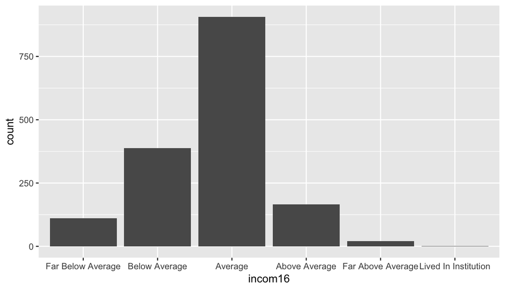

```r
ggplot(data = Income_status, aes(x=incom16))+geom_bar()
```

The spread of Above avarage and Not Above avarage.

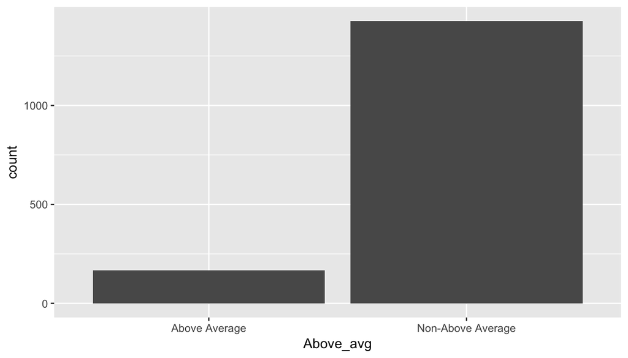

```r
ggplot(data = Income_status, aes(x=Above_avg))+geom_bar()
```

The number of male and female in this new table.

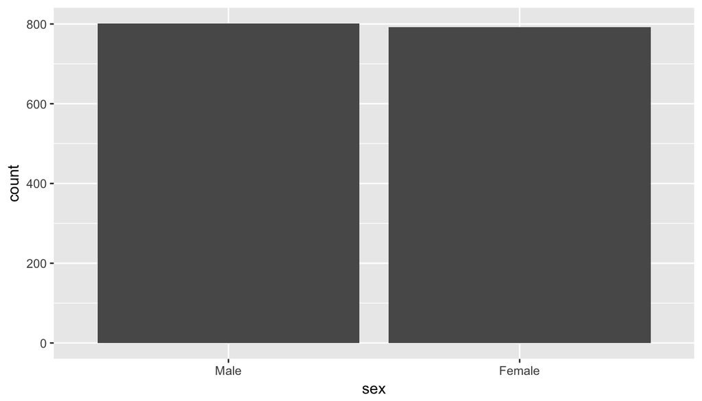

```r
ggplot(data = Income_status, aes(x=sex))+geom_bar()
```

* * *

## Part 4: Inference

Hypotheses: the popluationn proportion will state same as the proportion of sample. Check: Independt, np>10%, (1-p)n>10% Method: Theoretical becuase the sample proportion is known.

```r
413/1608
```

```
## [1] 0.2568408
```

```r
1195/1608
```

```
## [1] 0.7431592
```

```r
inference(y=True_false, data = Religious, type = "ci", statistic = "proportion", success = "Catholic", method = "theoretical" )
```

```
## Single categorical variable, success: Catholic
## n = 1608, p-hat = 0.2568
## 95% CI: (0.2355 , 0.2782)
```

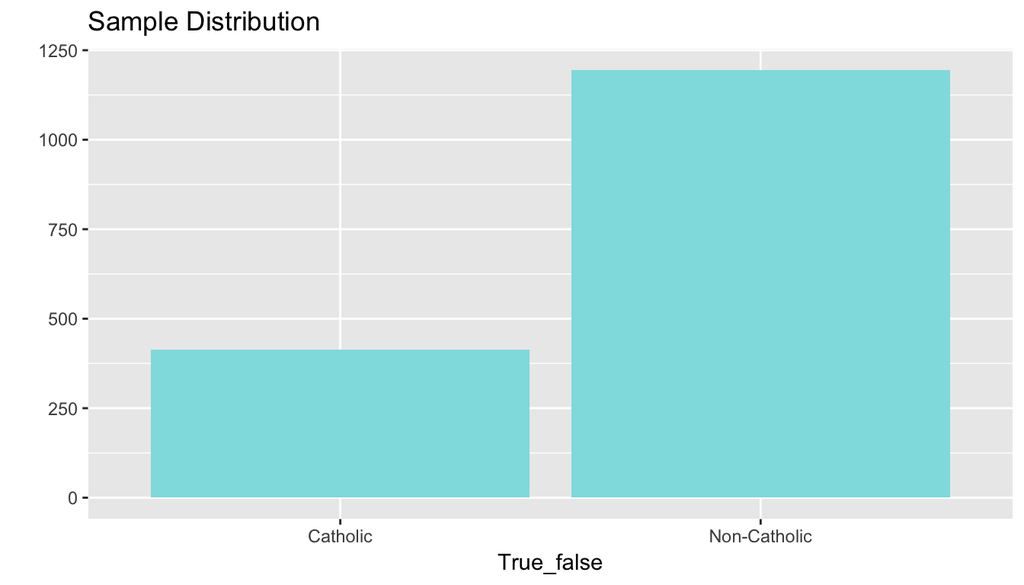

Accroding to the reslut, we are 95% confident that the proportion of Catholic in 1972 is between23.5% and 27.8%

Hypotheses: Null: There is not differece, Alternative: there is a difference. Check: Independent, np>10%, (1-p)n>10% Method: Theoretical- the proportion of Female and Male can be compared to each other

```r
inference(y=True_false, x= sex, data = Religious, type = "ht", statistic = "proportion", null = 0, alternative = "twosided",success ="Catholic", method = "theoretical" )
```

```
## Response variable: categorical (2 levels, success: Catholic)
## Explanatory variable: categorical (2 levels)
## n_Male = 804, p_hat_Male = 0.2724
## n_Female = 804, p_hat_Female = 0.2413
## H0: p_Male =  p_Female
## HA: p_Male != p_Female
## z = 1.427
## p_value = 0.1536
```

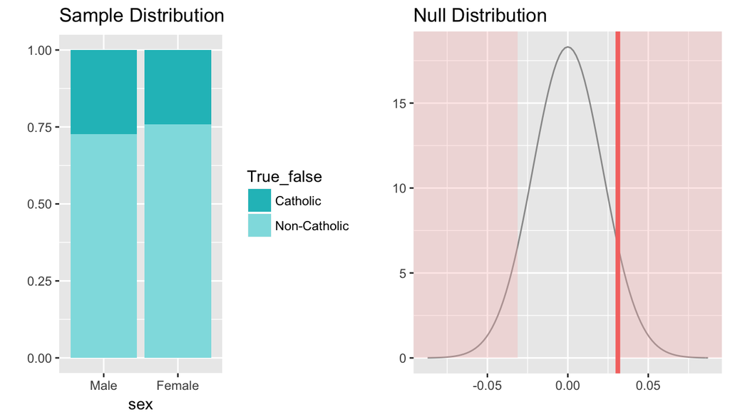

Accroding to the result, there is no strong evidence that indicate there is a difference between the proportion of female and male. So, we cannot refuse the Null hypothesis.

Hypotheses: Null: There is not differece, Alternative: there is a difference. Check: Independent, np>10%, (1-p)n>10% Method: Theoretical- the proportion of Female and Male can be compared to each other

```r
Income_status<-gss%>%
  filter(incom16!= "NA", year=="1972")%>%
  select(year,sex, incom16)
Income_status<-Income_status%>%
  mutate(Above_avg= ifelse(incom16=="Above Average", yes="Above Average", no="Non-Above Average"))

inference(y=Above_avg, x= sex, data = Income_status, type = "ht", statistic = "proportion", null = 0, alternative = "twosided",success ="Above Average", method = "theoretical")
```

```
## Response variable: categorical (2 levels, success: Above Average)
## Explanatory variable: categorical (2 levels)
## n_Male = 801, p_hat_Male = 0.1036
## n_Female = 792, p_hat_Female = 0.1048
## H0: p_Male =  p_Female
## HA: p_Male != p_Female
## z = -0.0769
## p_value = 0.9387
```

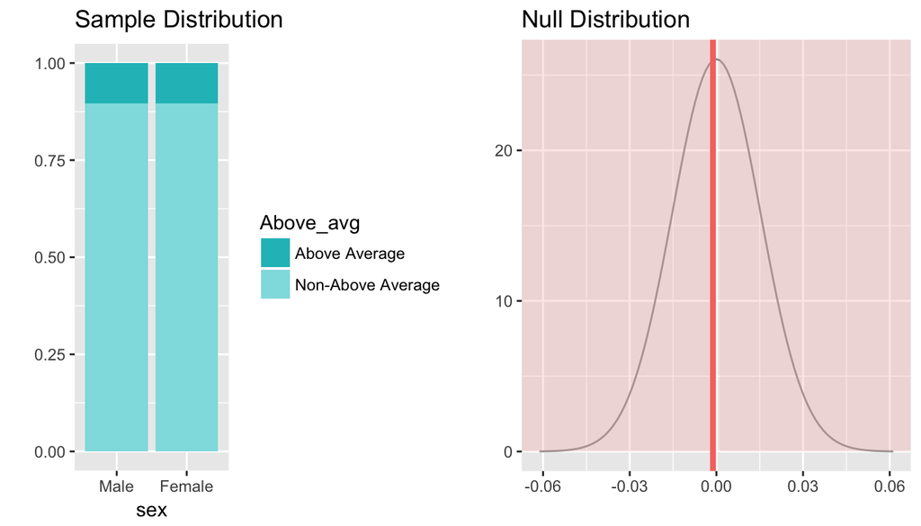

Accroding to the result, there is no strong evidence that indicate there is a difference between the proportion of female and male. So, we cannot refuse the Null hypothesis.